# Peer Commentary - Amita Ganesh

Sherry Xie

2025-02-07

# I think you did a really good job of annotating your code! It’s easy to follow and I feel like I can learn from that, too.

```r
#loading ggplot for the figures
library(ggplot2)
```

## 1. Probability of Hearing More than 8 Calls

```r
#originally resercher hears 15 calls
exact <- 15

#set up probability that she will hear 8 or more calls over the original 15 calls
#1- because we want 8 or more calls
eight_or_more <- 1 - ppois(8, exact)

#show result
eight_or_more
```

```
## [1] 0.9625535
```

## 2. Probability of Hearing No Calls

```r
#originally resercher hears 15 calls
exact <- 15

#set up probability that she will hear no calls over the original 15 calls
#I did not use 1 - (100 percent chance of hearing call), because she heard no calls and there are no greater than...
no_call <- ppois(0, exact)

#show result
no_call
```

```
## [1] 3.059023e-07
```

# Interesting…I used dpois because she is looking for the probablity of hearing exactly 0 calls, whereas in the previous question she was looking for 8 or more. I wonder how our outputs compare.

## 3. Probability of Hearing Exactly 3 Calls

```r
#originally resercher hears 15 calls
exact <- 15

#set up probability that she will hear 3 calls over the original 15 calls
#No 1- because we want EXCATLY 3 calls
three_calls <- ppois(3, exact)

#show result
three_calls
```

```
## [1] 0.0002113785
```

# Here I also used dpois. Thanks again for being so detailed in your annotations!

## 4. Plot the relevant Poisson mass function over the values in range 0 ≤ x ≤ 30

```r
# this is the x values for the range 0 ≤ x ≤ 30
x_range <- 0:30
poisson_mass_function <- dpois(x_range, exact)

summary(poisson_mass_function)
```

```
##      Min.   1st Qu.    Median      Mean   3rd Qu.      Max.
## 3.100e-07 1.226e-03 1.328e-02 3.225e-02 6.102e-02 1.024e-01
```

# Why do you use the summary function? What does that do?

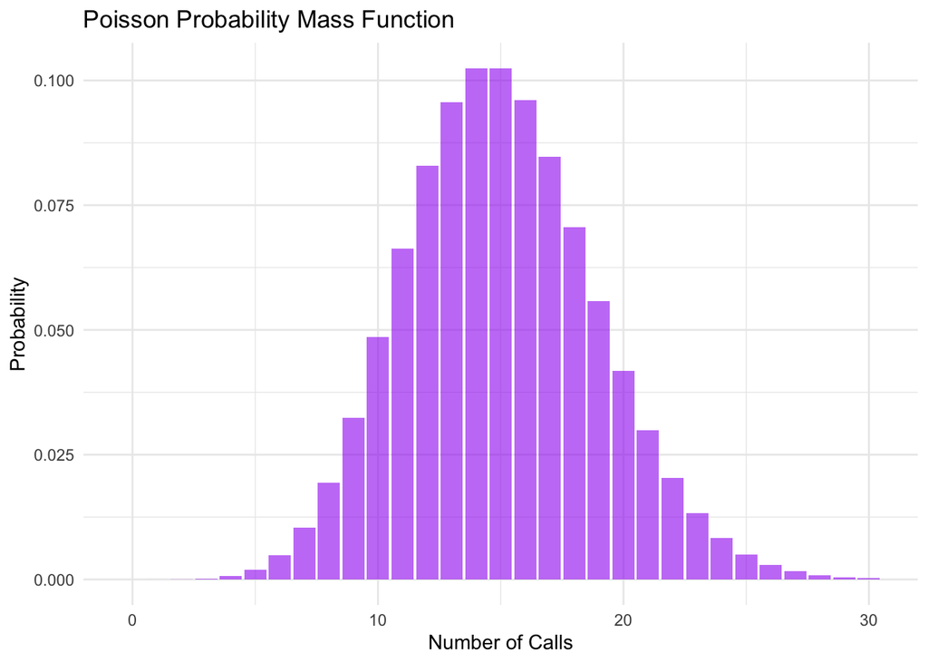

```r
# Plot PMF
#Import the data created above
ggplot(data = data.frame(x_range, poisson_mass_function), aes(x = x_range, y = poisson_mass_function)) +

  #i need to fill the data otherwise nothing shows up on my figure
    geom_bar(stat = "identity", fill = "purple", alpha = 0.6) +

  #figure title and organization
    labs(title = "Poisson Probability Mass Function",
         x = "Number of Calls", y = "Probability") +

  #prettifying by using a theme
    theme_minimal()
```

# Nice color choice! ## 5. Simulate 104 results from this distribution (i.e., 2 years of Saturday monitoring sessions).

```r
#originally resercher hears 15 calls
exact <- 15

# Simulate 104 Poisson-distributed monitoring sessions
#still over 15 as the original distribution: Average number of events per interval
# I used rpois: random density for poisson distribution instead of ppois which is probability distribution
stimulated_data <- rpois(104, exact)

#show result
stimulated_data
```

```
##   [1] 17 13 18 21 18 19 11 12 13 13 12 18 12 18 15 14 19 14 13 18 19 13 19 16 10
##  [26] 13 16 10  9  7 13  7 14  9 15 16 10 12 11 10 20 14 16 21 15 24  7 14 13  5
##  [51] 13 16 12 15 19 13 12 16 21 17  9 18 13 14 10 16 11 16 19 18 18 17 14 18 17
##  [76] 17 16 16 13 15 22 10 16 18 17 15 16 10 10 12 14 13 14 19 18 14 14 14 18 15
## [101] 10 14  9 16
```

```r
#provide a summary of the data: mean, median...
summary(stimulated_data)
```

```
##    Min. 1st Qu.  Median    Mean 3rd Qu.    Max.
##    5.00   12.00   14.00   14.55   17.00   24.00
```